# Introdução às Séries Temporais para Ciências Atuariais

**AR(1) com $r_1 > 0$**

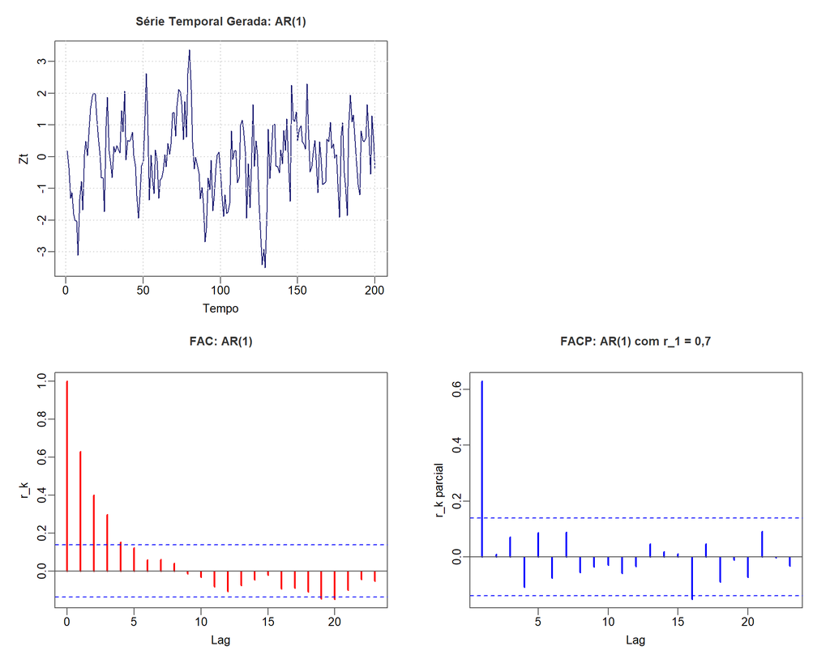

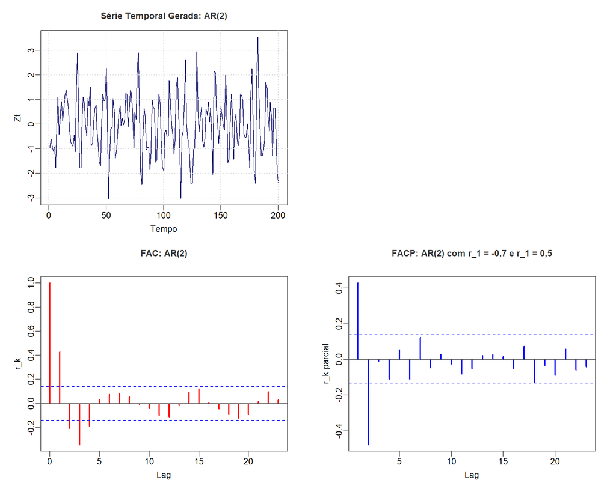

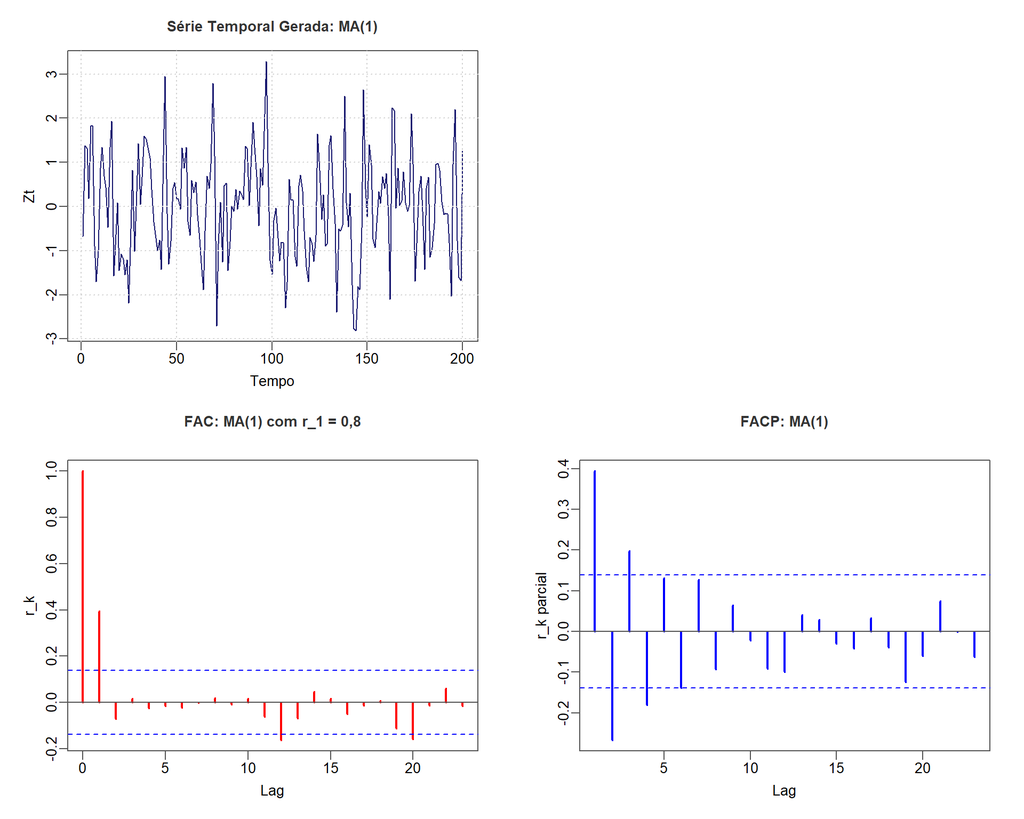

**MA(2) com $r_1 < 0$ e $r_2 > 0$**

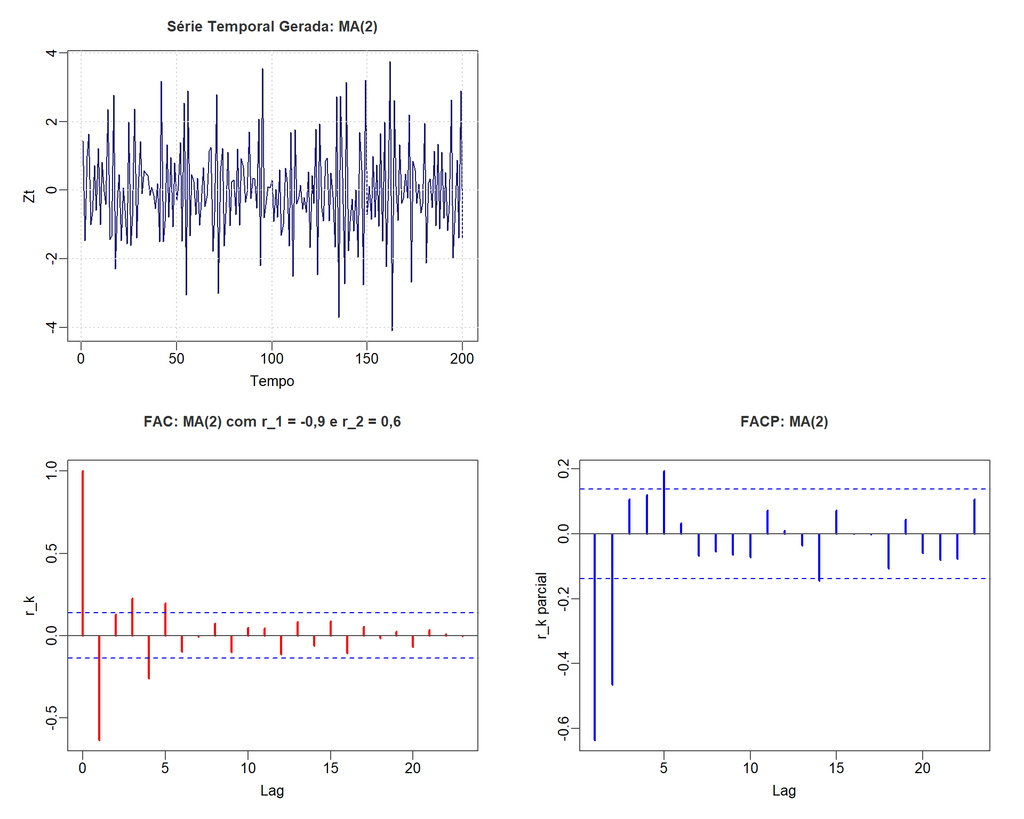

**ARIMA(2,0,2)**

[figure not shown]

#### **4.4 Invetibilidade e Estacionariedade**

O Quadro abaixo reúne, de forma resumida, as condições de estacionariedade e invertibilidade para os processos AR, MA e ARMA de ordens 1, 2 e 3.

Como os processos MA e AR possuem condições matemáticas perfeitamente simétricas (raízes fora do círculo unitário), as restrições de invertibilidade do MA espelham exatamente as restrições de estacionariedade do AR, trocando apenas os coeficientes $\phi$ por $\theta$.

**Quadro Resumo: Condições de Estacionariedade e Invertibilidade**

Processo

Ordem

Condição de Estacionariedade (parâmetros $\phi$)

Condição de Invertibilidade (parâmetros $\theta$)

AR($p$)

1

$|\phi_1| < 1$

Sempre invertível

2

- $\phi_2 + \phi_1 < 1$
- $\phi_2 - \phi_1 < 1$
- $|\phi_2| < 1$

Sempre invertível

3

- $\phi_1 + \phi_2 + \phi_3 < 1$
- $-\phi_1 + \phi_2 - \phi_3 < 1$
- $|\phi_3| < 1$
- $\phi_3(\phi_1 + \phi_3) - \phi_2 < 1$ (Não Linear)

Sempre invertível

MA($q$)

1

Sempre estacionário

$|\theta_1| < 1$

2

Sempre estacionário

- $\theta_2 + \theta_1 < 1$
- $\theta_2 - \theta_1 < 1$
- $|\theta_2| < 1$

3

Sempre estacionário

- $\theta_1 + \theta_2 + \theta_3 < 1$
- $-\theta_1 + \theta_2 - \theta_3 < 1$
- $|\theta_3| < 1$
- $\theta_3(\theta_1 + \theta_3) - \theta_2 < 1$ (Não Linear)

ARMA($p,q$)

(1,1)

$|\phi_1| < 1$

$|\theta_1| < 1$

(2,2)

As mesmas 3 condições do **AR(2)** aplicadas a $\phi$.

As mesmas 3 condições do **MA(2)** aplicadas a $\theta$.

(3,3)

As mesmas 4 condições do **AR(3)** aplicadas a $\phi$.

As mesmas 4 condições do **MA(3)** aplicadas a $\theta$.

#### **Exercícios**

Os Gráficos abaixo mostram duas séries nativas do R. A primeira (`discoveries`) mostra o número de grandes invenções científicas por ano no período de de 1860 a 1959. É uma série que flutua em torno de uma média constante, mas possui uma dependência temporal de curto prazo muito clara (característica de processos AR).

A segunda série (`lynx`) mostra o número de lince-pardo capturados anualmente no Canadá no período de 1821 a 1934. É uma série cíclica/sazonal (ciclos de aproximadamente 9 a 10 anos devido à relação predador-presa).

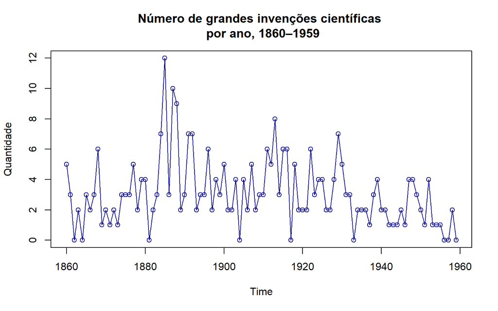

```r
# Carregar os dados nativos
data("discoveries")
data("lynx")

# Mudar layout para ver as duas séries lado a lado
par(mfrow = c(1, 1))
plot(discoveries, type = "o", col = "darkblue", main = "Número de grandes invenções científicas \n por ano, 1860–1959", ylab = "Quantidade")
```

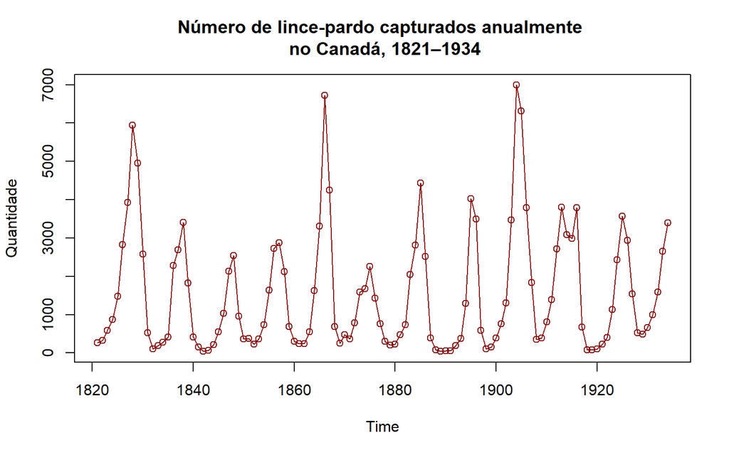

```r
plot(lynx, type = "o", col = "darkred", main = "Número de lince-pardo capturados anualmente \n no Canadá, 1821–1934", ylab = "Quantidade")
```

Os diagramas de dispersão mostrarão correlações que mudam de sinal conforme o lag aumenta, o que explodirá visualmente no correograma.

**ESTRATÉGIA 1: Diagramas de Dispersão e Cálculo Manual das Autocorrelações**

Para criar os gráficos de dispersão entre $Z_t$ e suas defasagens ($Z_{t-1}, Z_{t-2}, Z_{t-3}$), usaremos a função lag() ou criaremos os vetores alinhados manualmente para garantir que os comprimentos batam perfeitamente.

**Análise para a Série 1 (`discoveries`)**

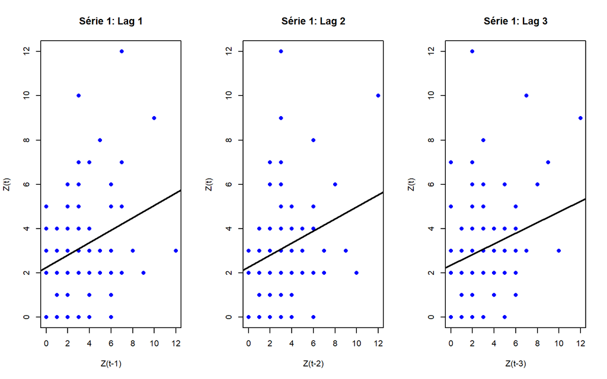

```r
# Organizar o layout para 3 gráficos de dispersão (1 linha, 3 colunas)
par(mfrow = c(1, 3))

# Criando as séries defasadas manualmente para garantir o alinhamento
n1 <- length(discoveries)
Zt_1     <- discoveries[4:n1] # Série original (truncada para alinhar com lag 3)
Zt_lag1  <- discoveries[3:(n1-1)]   # Lag 1
Zt_lag2  <- discoveries[2:(n1-2)]   # Lag 2
Zt_lag3  <- discoveries[1:(n1-3)]   # Lag 3

# Plot dos Diagramas de Dispersão
plot(Zt_lag1, Zt_1, main = "Série 1: Lag 1", xlab = "Z(t-1)", ylab = "Z(t)", col = "blue", pch = 16)
abline(lm(Zt_1 ~ Zt_lag1), col = "black", lwd = 2) # Linha de tendência para ilustrar a correlação

plot(Zt_lag2, Zt_1, main = "Série 1: Lag 2", xlab = "Z(t-2)", ylab = "Z(t)", col = "blue", pch = 16)
abline(lm(Zt_1 ~ Zt_lag2), col = "black", lwd = 2)

plot(Zt_lag3, Zt_1, main = "Série 1: Lag 3", xlab = "Z(t-3)", ylab = "Z(t)", col = "blue", pch = 16)
abline(lm(Zt_1 ~ Zt_lag3), col = "black", lwd = 2)
```

```r
# Cálculo numérico das correlações amostrais de Pearson para cada par
r1_lag1 <- cor(Zt_1, Zt_lag1)
r1_lag2 <- cor(Zt_1, Zt_lag2)
r1_lag3 <- cor(Zt_1, Zt_lag3)

# Print dos resultados manuais
cat("Série 1 (Invenções) - Autocorrelações via Scatter Plot:\n")
```

```
## Série 1 (Invenções) - Autocorrelações via Scatter Plot:
```

```r
cat("Lag 1:", round(r1_lag1, 4), "\n")
```

```
## Lag 1: 0.2813
```

```r
cat("Lag 2:", round(r1_lag2, 4), "\n")
```

```
## Lag 2: 0.2712
```

```r
cat("Lag 3:", round(r1_lag3, 4), "\n\n")
```

```
## Lag 3: 0.2389
```

**Análise para a Série 2 (`lynx`)**

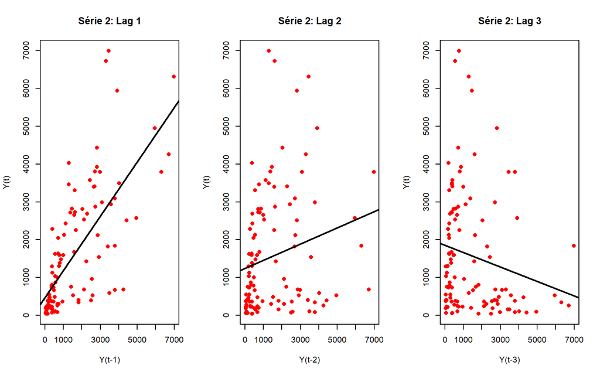

```r
# Organizar o layout para a segunda série
par(mfrow = c(1, 3))

n2 <- length(lynx)
Yt_1     <- lynx[4:n2]
Yt_lag1  <- lynx[3:(n2-1)]
Yt_lag2  <- lynx[2:(n2-2)]
Yt_lag3  <- lynx[1:(n2-3)]

# Plot dos Diagramas de Dispersão
plot(Yt_lag1, Yt_1, main = "Série 2: Lag 1", xlab = "Y(t-1)", ylab = "Y(t)", col = "red", pch = 16)
abline(lm(Yt_1 ~ Yt_lag1), col = "black", lwd = 2)

plot(Yt_lag2, Yt_1, main = "Série 2: Lag 2", xlab = "Y(t-2)", ylab = "Y(t)", col = "red", pch = 16)
abline(lm(Yt_1 ~ Yt_lag2), col = "black", lwd = 2)

plot(Yt_lag3, Yt_1, main = "Série 2: Lag 3", xlab = "Y(t-3)", ylab = "Y(t)", col = "red", pch = 16)
abline(lm(Yt_1 ~ Yt_lag3), col = "black", lwd = 2)
```

```r
# Cálculo das correlações
r2_lag1 <- cor(Yt_1, Yt_lag1)
r2_lag2 <- cor(Yt_1, Yt_lag2)
r2_lag3 <- cor(Yt_1, Yt_lag3)

cat("Série 2 (Lynx) - Autocorrelações via Scatter Plot:\n")
```

```
## Série 2 (Lynx) - Autocorrelações via Scatter Plot:
```

```r
cat("Lag 1:", round(r2_lag1, 4), "\n")
```

```
## Lag 1: 0.7146
```

```r
cat("Lag 2:", round(r2_lag2, 4), "\n")
```

```
## Lag 2: 0.2143
```

```r
cat("Lag 3:", round(r2_lag3, 4), "\n")
```

```
## Lag 3: -0.1912
```

**ESTRATÉGIA 2: Correlogramas Oficiais (FAC) e Comparação de Valores**

Nesta etapa, geraramos a Função de Autocorrelação utilizando o comando acf() e extraindo os valores numéricos gerados pela função e comparando-os com os valores calculado na ESTRATÉGIA 1.

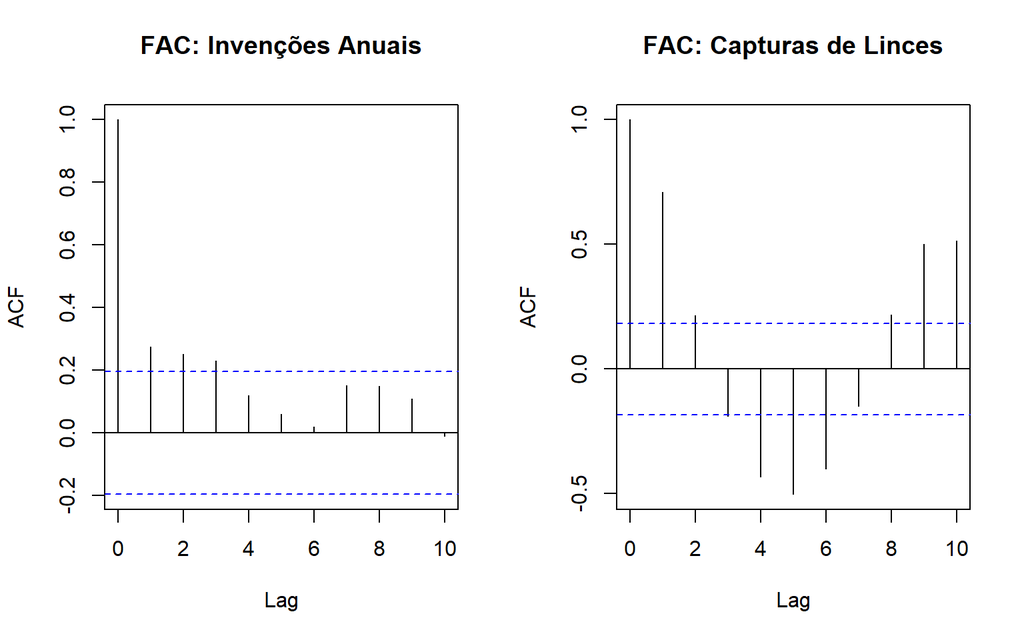

```r
# Restaurar layout para duas imagens
par(mfrow = c(1, 2))

# Gerar os correlogramas visuais
fac_discoveries <- acf(discoveries, lag.max = 10, main = "FAC: Invenções Anuais")
fac_lynx        <- acf(lynx, lag.max = 10, main = "FAC: Capturas de Linces")
```

```r
# Extrair os valores exatos da FAC calculados pelo R (o índice [1] equivale ao lag 0, que é sempre 1)
valores_fac1 <- fac_discoveries$acf[2:4] # lags 1, 2 e 3
valores_fac2 <- fac_lynx$acf[2:4]        # lags 1, 2 e 3

# Criar tabelas comparativas para exibição no console
tabela_serie1 <- data.frame(
  Lag = 1:3,
  Calculo_Manual = c(r1_lag1, r1_lag2, r1_lag3),
  FAC     = valores_fac1
)

tabela_serie2 <- data.frame(
  Lag = 1:3,
  Calculo_Manual = c(r2_lag1, r2_lag2, r2_lag3),
  FAC     = valores_fac2
)

print("--- COMPARAÇÃO: SÉRIE 1 ---")
```

```
## [1] "--- COMPARAÇÃO: SÉRIE 1 ---"
```

```r
print(tabela_serie1)
```

```
##   Lag Calculo_Manual       FAC
## 1   1      0.2812697 0.2741352
## 2   2      0.2711717 0.2520477
## 3   3      0.2388949 0.2309543
```

```r
print("--- COMPARAÇÃO: SÉRIE 2 ---")
```

```
## [1] "--- COMPARAÇÃO: SÉRIE 2 ---"
```

```r
print(tabela_serie2)
```

```
##   Lag Calculo_Manual        FAC
## 1   1      0.7146362  0.7108187
## 2   2      0.2142824  0.2144115
## 3   3     -0.1911877 -0.1885254
```

**Discussão do resultado**

Pelos resultados apresentados, nota-se que os valores calculados manualmente na Estratégia 1 são muito próximos, mas não idênticos aos valores gerados pela função acf() na Estratégia 2.

Isso ocorre porque no cálculo manual da Estratégia 1 (cor()), a fórmula do coeficiente de correlação calcula a média e a variância de cada vetor truncado separadamente. Ou seja, a média de $Z_t$ é ligeiramente diferente da média de $Z_{t-1}$ porque os vetores não possuem exatamente as mesmas observações nas pontas.

Na estratégia utilizando a FAC (acf()), a média ($\mu$) e a variância ($\sigma^2$) utilizadas no denominador e no numerador são calculadas utilizando a série histórica inteira.

Para ver isso com mais detalhes, vamos considerar a primeira série (`discoveries`). Esta série possui $n = 100$ observações. Para calcular o Lag 1 e fazer o gráfico de dispersão da sérei com suas defasgens devemos fatiar a série em dois vetores de tamanho 99:

- Vetor 1 ($Z_t$): Da observação 2 até a 100.
- Vetor 2 ($Z_{t-1}$): Da observação 1 até a 99.

A função `cor()`, utilizada na estratégia 1, trata esses dois vetores como duas variáveis quaisquer e independentes. Portanto, ela calcula a média do Vetor 1 ($\bar{Z}_t$) usando apenas os pontos de 2 a 100, e a média do Vetor 2 ($\bar{Z}_{t-1}$) usando apenas os pontos de 1 a 99. Como as observações das pontas (a 1ª e a 100ª) foram deixadas de fora em um dos vetores, as duas médias serão ligeiramente diferentes. O mesmo acontece com os desvios padrões de cada vetor.

A função `acf()`, utilizada na estratégia 2, assume que os dados vieram de uma única série temporal estacionária. Por definição, um processo estacionário possui uma única média global constante e uma única variância global.

Por isso, a função `acf()` calcula a média ($\bar{Z}$) e a variância usando todos os 100 pontos da série original, antes de fazer qualquer defasagem. Ela usa essa mesma média e variância global para o cálculo de todos os lags (seja Lag 1, Lag 2 ou Lag 50). Matematicamente, as fórmulas aplicadas são:

- Na Estratégia 1 (cor):

$$\rho_k^{\text{manual}} = \frac{\sum (Z_t
- \bar{Z}_t)(Z_{t-k} - \bar{Z}_{t-k})}{\sqrt{\sum (Z_t - \bar{Z}_t)^2}
\sqrt{\sum (Z_{t-k} - \bar{Z}_{t-k})^2}}$$

- Na Estratégia 2 (acf):

$$\rho_k^{\text{fac}} =
\frac{\sum_{t=k+1}^{n} (Z_t - \bar{Z})(Z_{t-k} -
\bar{Z})}{\sum_{t=1}^{n} (Z_t - \bar{Z})^2}$$

Note que na fórmula utilizada na função `acf()`, o denominador é a variância total da série multiplicada por $n$, e não o produto de dois desvios padrões amostrais de vetores truncados.

Essas pequenas diferenças nos valores das autocorrelações entre as duas estratágias nos suscitam um debate clássico e muito importante na formação de cientistas atuariais e estatísticos: qual estimador devemos preferir quando temos amostras reais (finitas)?

O estimador usado pela função `acf()` é viesado em amostras finitas. Como ele divide a soma dos produtos por $n$ (o tamanho total da série) e não por $n-k$ (o número de pares que realmente restaram após a defasagem), ele tende a subestimar a autocorrelação real à medida que o lag $k$ aumenta.

Por outro lado, o estimador da função `cor()` ajusta-se dinamicamente ao tamanho dos vetores restantes, mas quebra a premissa de que a série possui propriedades estatísticas constantes ao longo do tempo (estacionariedade).

**Consistência Assintótica (O que acontece quando a amostra cresce?)**

O conceito de propriedade assintótica estuda o comportamento de um estimador quando o tamanho da amostra ($n$) tende ao infinito ($n \to \infty$).

À medida que a amostra cresce (digamos, se passarmos de $n = 100$ para $n = 100.000$ observações), o impacto de retirar uma ou duas observações das pontas para alinhar os lags torna-se estatisticamente irrelevante, ou seja:

- A média do vetor truncado ($\bar{Z}_t$) vai convergir exatamente para a média global ($\bar{Z}$).
- O peso de dividir por $n$ ou por $n-k$ vai se tornar idêntico.

Portanto, assintoticamente, os dois estimadores são equivalentes e convergem para o mesmo valor real da população.

### **Declaração de Uso de Inteligência Artificial**

Declaro que ferramentas de Inteligência Artificial Generativa (IA) foram utilizadas como suporte na elaboração deste curso, especificamente nas seguintes etapas:

- **Desenvolvimento de Scripts:** Auxílio na estruturação de códigos em linguagem R para a geração de visualizações de dados e gráficos interativos.
- **Formatação Técnica:** Suporte na redação de sintaxe LaTeX integrada ao ambiente R Markdown.
- **Aprimoramento Textual:** Revisão gramatical, ortográfica e estilística da redação original.

Declaro, ainda, que o conteúdo foi revisado está em conformidade com a Portaria 2664/2026 do CNPq.

### **Referências**

*Análise de séries Temporais Em r: Curso Introdutório*. 2017. GEN Atlas. https://books.google.com.br/books?id=wQn0zwEACAAJ.

Box, George EP, Gwilym M Jenkins, Gregory C Reinsel, and Greta M Ljung. 2015. *Time Series Analysis: Forecasting and Control*. John Wiley & Sons.

Box, George, and GM Jenkins. 1976. “Analysis: Forecasting and Control.” *San Francisco* 10.

Brockwell, Peter J, and Richard A Davis. 2002. *Introduction to Time Series and Forecasting*. Springer.

Cowpertwait, Paul SP, and Andrew V Metcalfe. 2009. *Introductory Time Series with r*. Springer Science & Business Media.

Dickey, David A, and Wayne A Fuller. 1979. “Distribution of the Estimators for Autoregressive Time Series with a Unit Root.” *Journal of the American Statistical Association* 74 (366a): 427–31.

Eliot, G, TJ Rothenberg, and JH Stock. 1996. “Efficient Test for an Autoregressive Unit Root.” *Econometrica* 64 (4): 813–36.

Holt, Charles C. 1957. *Forecasting Seasonals and Trends by Exponentially Weighted Moving Averages*.

Holt, Charles C. 2004. “Forecasting Seasonals and Trends by Exponentially Weighted Moving Averages.” *International Journal of Forecasting* 20 (1): 5–10.

Kwiatkowski, Denis, Peter CB Phillips, Peter Schmidt, and Yongcheol Shin. 1992. “Testing the Null Hypothesis of Stationarity Against the Alternative of a Unit Root: How Sure Are We That Economic Time Series Have a Unit Root?” *Journal of Econometrics* 54 (1-3): 159–78.

Morettin, Pedro Alberto, and Clélia Maria de Castro Toloi. 2022. *Análise de séries Temporais*.

Phillips, Peter CB, and Pierre Perron. 1988. “Testing for a Unit Root in Time Series Regression.” *Biometrika* 75 (2): 335–46.

Shumway, Robert H, and David S Stoffer. 2006. *Time Series Analysis and Its Applications: With r Examples*. Springer.

Winters, Peter R. 1960. “Forecasting Sales by Exponentially Weighted Moving Averages.” *Management Science* 6 (3): 324–42.

Zivot, Eric, and Donald W K Andrews. 2002. “Further Evidence on the Great Crash, the Oil-Price Shock, and the Unit-Root Hypothesis.” *Journal of Business & Economic Statistics* 20 (1): 25–44.